# Pre-Covid U.S. Airline Traffic Analysis

### Model Diagnostics & Residual Analysis

After selecting the most appropriate SARIMA model for the data available, residuals are examined for:

- Constant variance (Homoscedasticity)
- Normality using the Shapiro-Wilk test
- Independence using the Ljung-Box test

```
##
##  studentized Breusch-Pagan test
##
## data:  lm(residuals_sarima ~ time_series)
## BP = 1.3537, df = 1, p-value = 0.2446
```

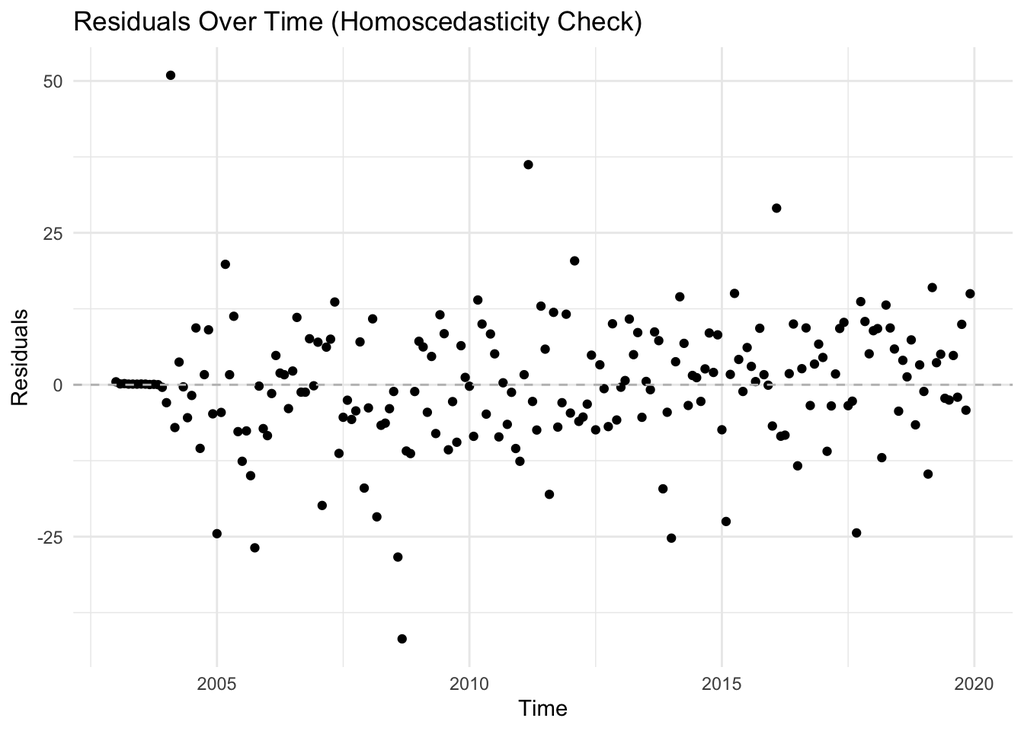

```
##
##  Box-Ljung test
##
## data:  residuals_sarima
## X-squared = 0.045198, df = 1, p-value = 0.8316
```

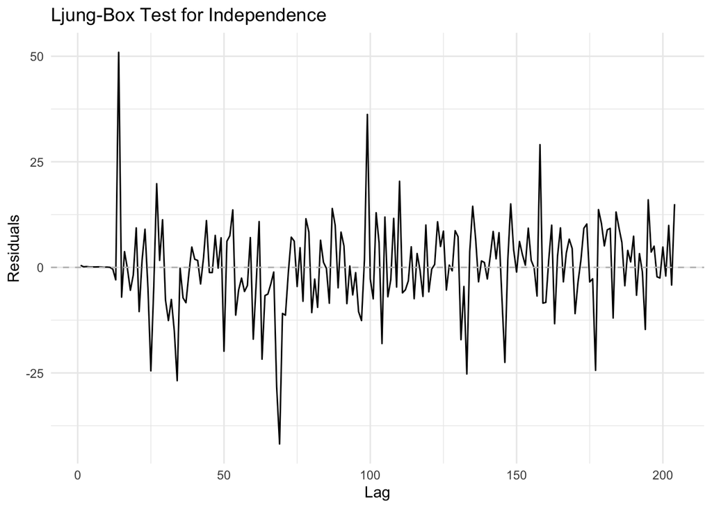

```
##
##  Shapiro-Wilk normality test
##
## data:  residuals_sarima
## W = 0.94399, p-value = 4.125e-07
```

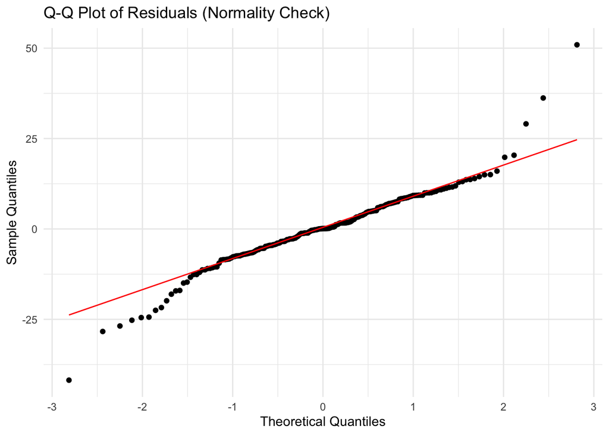

### Insights based on Residual Diagnostics

Independence Check (Box-Ljung Test)

The residual plot from the Box-Ljung test exhibits fluctuations around zero, with some spikes at specific lags, suggesting potential autocorrelation in the residuals.

- The p-value of the Box-Ljung test is 0.8316, which is relatively large.
  - This indicates that there is no strong evidence to reject the null hypothesis of independence in the residuals.
  - In other words, the residuals appear to be independent, and there is no significant autocorrelation detected.

Constant Variance Check (Homoscedasticity)

The residual scatter plot over time suggests that the spread of residuals remains relatively constant, implying no strong evidence of heteroscedasticity.

- However, some points exhibit higher deviations, which might indicate localized periods of increased variance.
- Additional testing (e.g., Breusch-Pagan test) may help confirm homoscedasticity assumptions.

Normality Check (Q-Q Plot)

The Q-Q plot of residuals suggests deviations from normality, particularly at the tails, where residuals exhibit larger-than-expected deviations.

# Conclusion

This project added to the pool of knowledge about the trend and seasonality in air traffic data that were present pre-COVID 19 and insight into possible models that might be appropriate for this data. However, as much as we would like to be able to use our chosen model to construct accurate forecasts for the time period post 2019, further analysis would have to be done to handle the unexpected event of COVID 19, which dramatically affected the course of the air traffic data.

Overall, this project presented a comprehensive time series analysis of air traffic data pre-COVID 19 in order to increase the general understanding of how the airline industry behaves over time. Moreover, this type of analysis is incredibly important because it offers insight into how the airline industry can structure future improvements to optimize overall efficiency in regards to the volume of flights offered each month.

## References

#### References for section “Introduction” and “Exploratory Data Analysis (EDA)”

[1] Air Transport Action Group. (n.d.). Supporting economic and social development. Air Transport Action Group. Retrieved from https://atag.org/industry-topics/supporting-economic-social-development

[2] Durgut, M. (2023, February 5). Importance of historical data in air traffic management. AviationFile. Retrieved from https://www.aviationfile.com/importance-of-historical-data-in-air-traffic-management/

[3] Yuan, X. (2018). U.S. Airline Traffic Data. Kaggle. https://www.kaggle.com/datasets/yyxian/u-s-airline-traffic-data?resource=download

[4] FasterCapital. (2024). Trend analysis: Seasonal variations – seasons of change: Incorporating seasonal variations into trend analysis. FasterCapital. Retrieved from https://fastercapital.com/content/Trend-analysis--Seasonal-Variations--Seasons-of-Change--Incorporating-Seasonal-Variations-into-Trend-Analysis.html

[5] Goldman, D. (2008, July 15). Airlines face more turbulence amid high fuel prices. CNNMoney. Retrieved from https://money.cnn.com/2008/07/15/news/economy/airlines/

[6] U.S. Government Accountability Office. (2014, April). Aviation: The Federal Aviation Administration’s efforts to address air traffic controller staffing and flight delays (GAO-14-331). U.S. Government Accountability Office. Retrieved from https://www.gao.gov/products/gao-14-331

[7] Leonie, I. (2022). Time series: Interpreting ACF and PACF. Kaggle. Retrieved from https://www.kaggle.com/code/iamleonie/time-series-interpreting-acf-and-pacf

#### References for Section “Trend and Seasonality Analysis”

[1] https://online.stat.psu.edu/stat510/lesson/5/5.1

[2] https://otexts.com/fpp2/stl.html

[3] https://datascience.stackexchange.com/questions/46050/additive-vs-multiplicative-model-in-time-series-data

[4] https://www.pnas.org/doi/10.1073/pnas.0701020104

[5] https://en.wikipedia.org/wiki/Discrete_Fourier_transform

[6] https://en.wikipedia.org/wiki/Periodogram

#### References for section “Model Selection”

[1] Ionides, E. (2025). *Time Series Analysis - Chapter 3: Introduction to ARMA Models*. University of Michigan. Retrieved from https://ionides.github.io/531w25/03/index.html  
- Used in the introduction to ARMA models section.

[2] Ionides, E. (2025). *Time Series Analysis - Chapter 5: ARMA Model Parameter Estimation*. University of Michigan. Retrieved from https://ionides.github.io/531w25/05/index.html  
- Used in the ARMA model selection section, specifically in parameter estimation.

[3] Ionides, E. (2025). *Time Series Analysis - Chapter 6: SARIMA Models*. University of Michigan. Retrieved from https://ionides.github.io/531w25/06/index.html  
- Used in the SARIMA modeling section, guiding the seasonal differencing and parameter selection.

[4] Ionides, E. (2024). *Midterm Project References*. University of Michigan. Retrieved from https://ionides.github.io/531w24/midterm_project/project05/blinded.html#References  
- Used for formatting the unit root test graphs, particularly visualization techniques adapted for ADF tests.